# Étude de la production de pommes

### Les élasticités

- Calculez pour chaque firme l’élasticité de l’output par rapport à chacun des trois inputs capital,travail et matériaux.
- Calculer la moyenne de ces élasticités sur l’échantillon.
- Représentez la distribution empirique des ces élasticités.

$$\epsilon_i = \frac{\partial f(x)}{\partial x_i} \frac {x_i}{f(x)}$$

```
##   eps_cap   eps_lab   eps_mat
## 0.1202721 2.0734793 0.8631936
```

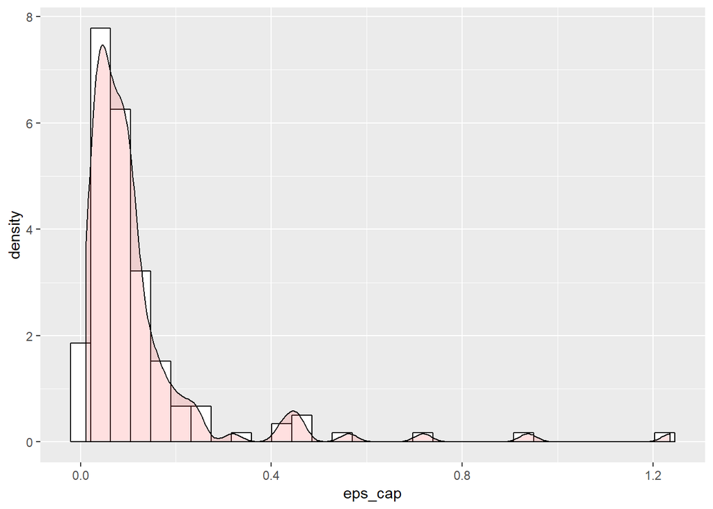

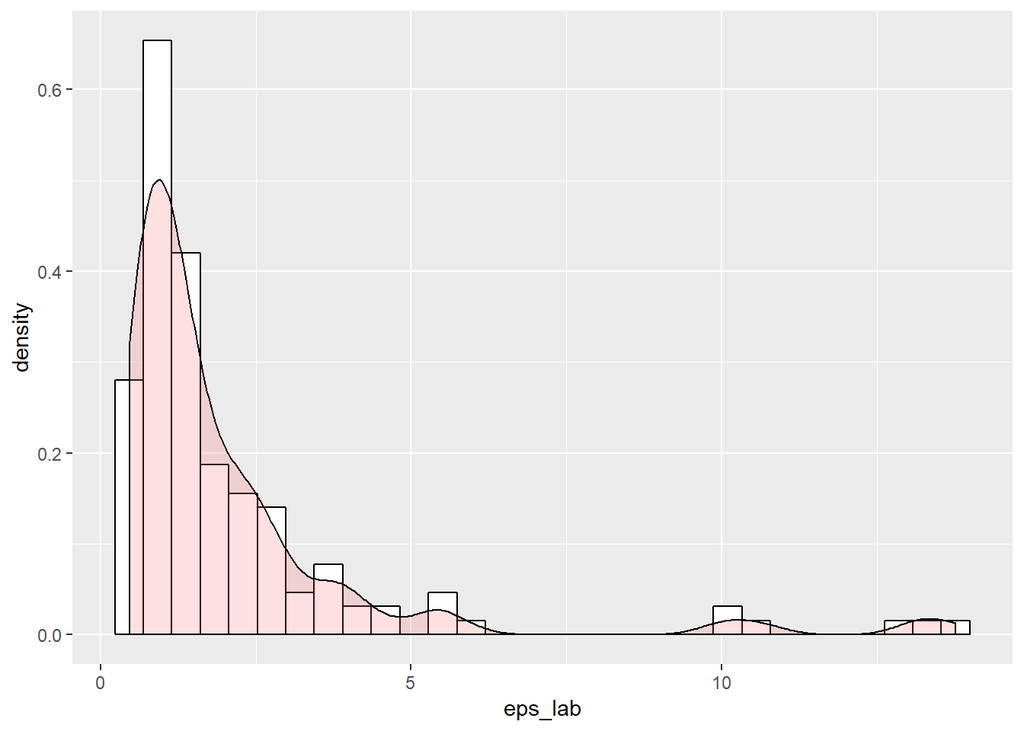

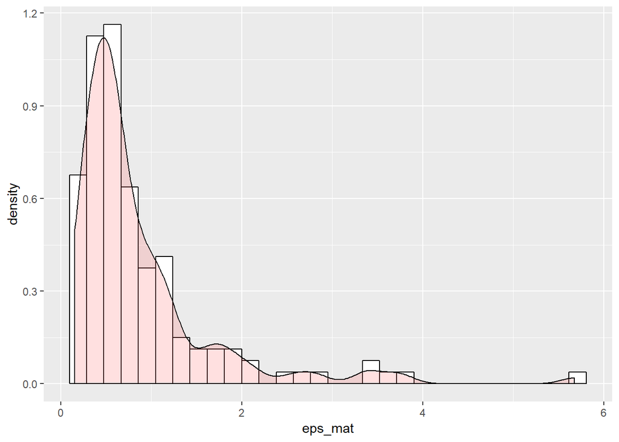

```
## eps_cap_fit eps_lab_fit eps_mat_fit
##   0.1421941   2.2142092   0.9784056
```

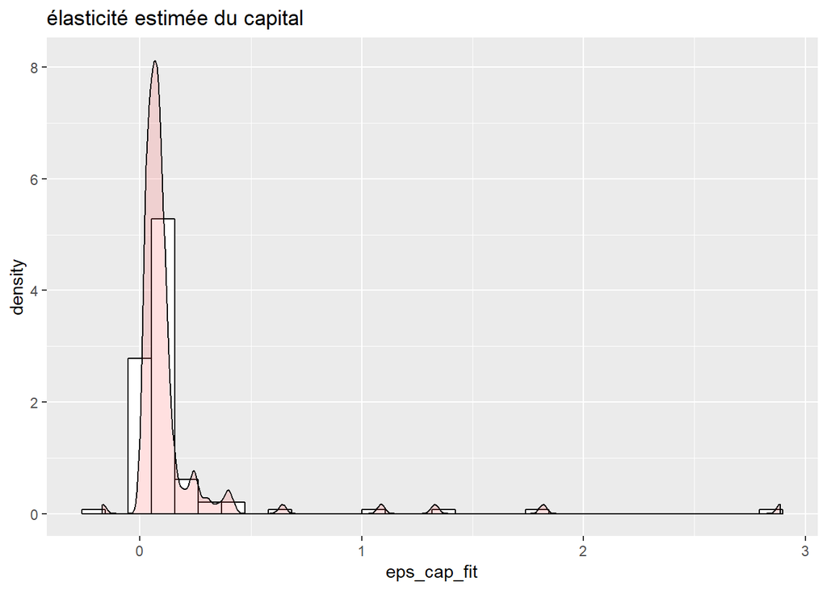

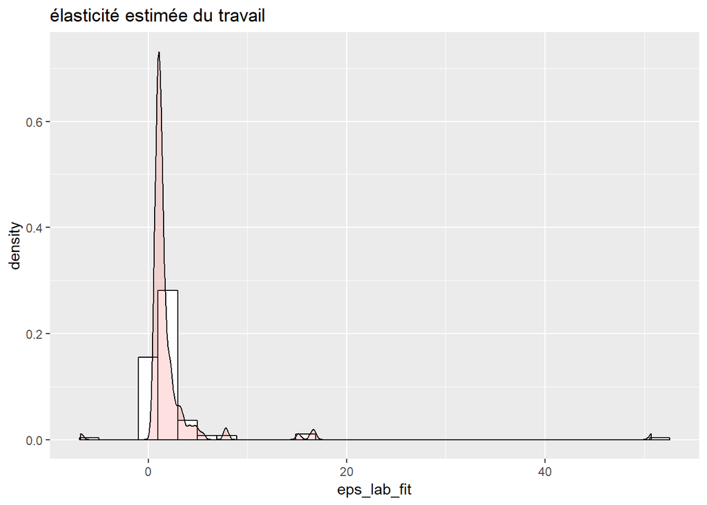

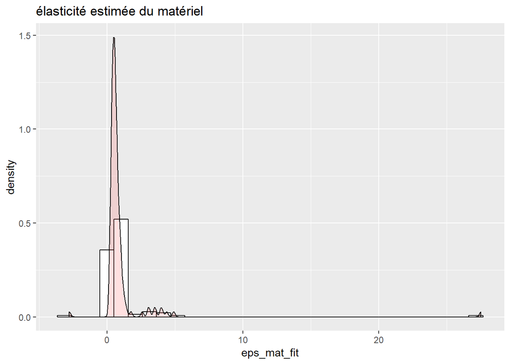

```
##     eps_echelle eps_echelle_fit
##        3.056945        3.334809
```

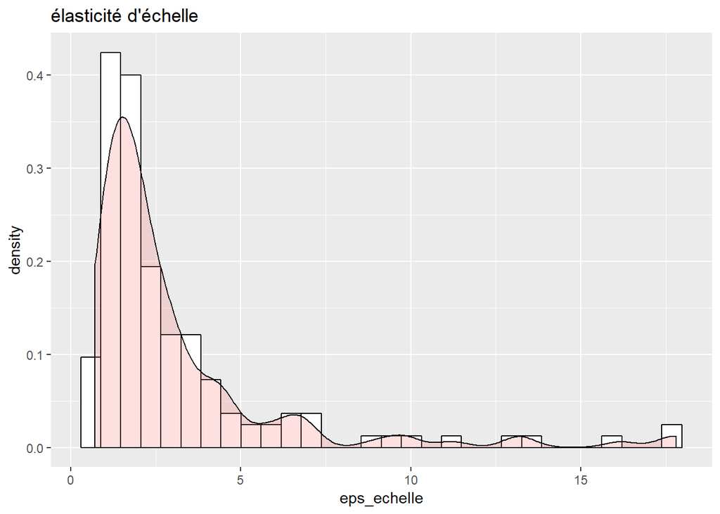

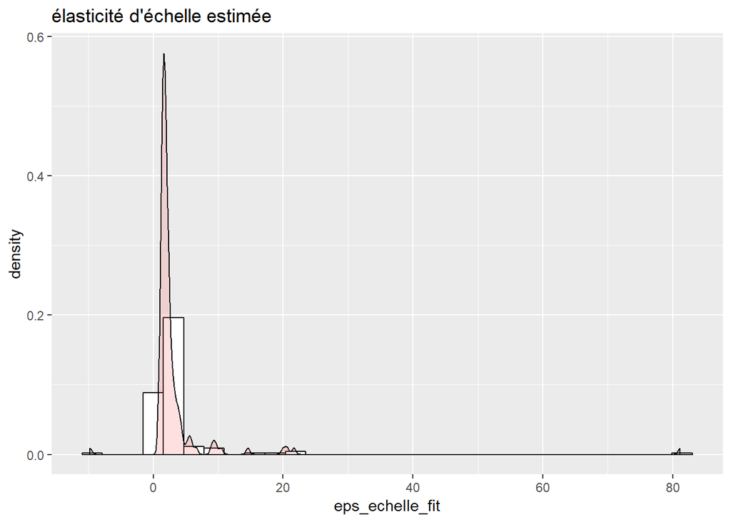

```
tmrst_CapLab tmrst_MatLab
  -24.240195    -2.507823
```

**Normalité des résidus**

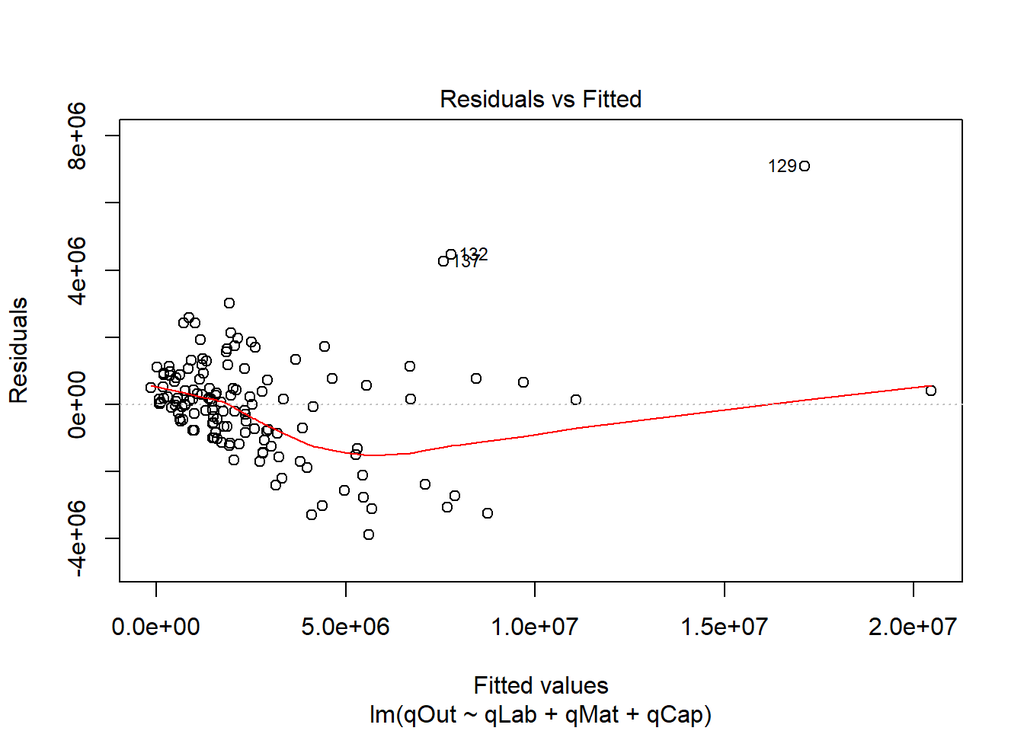

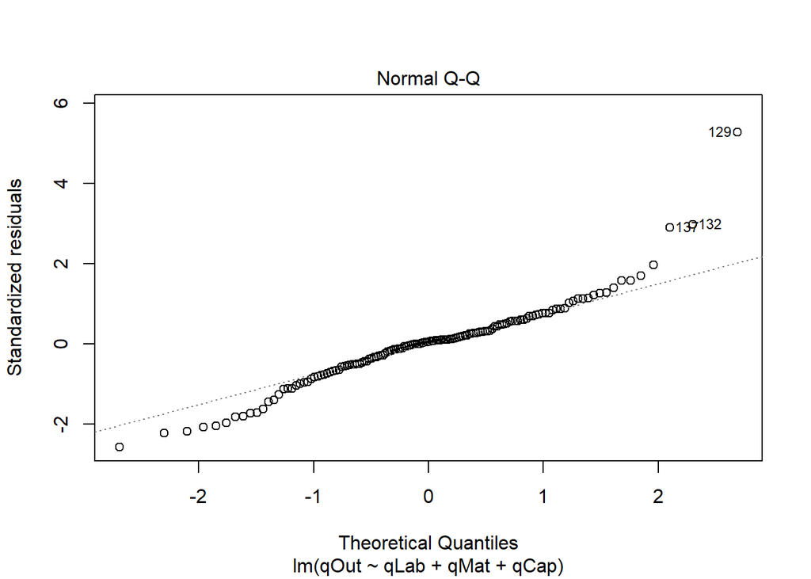

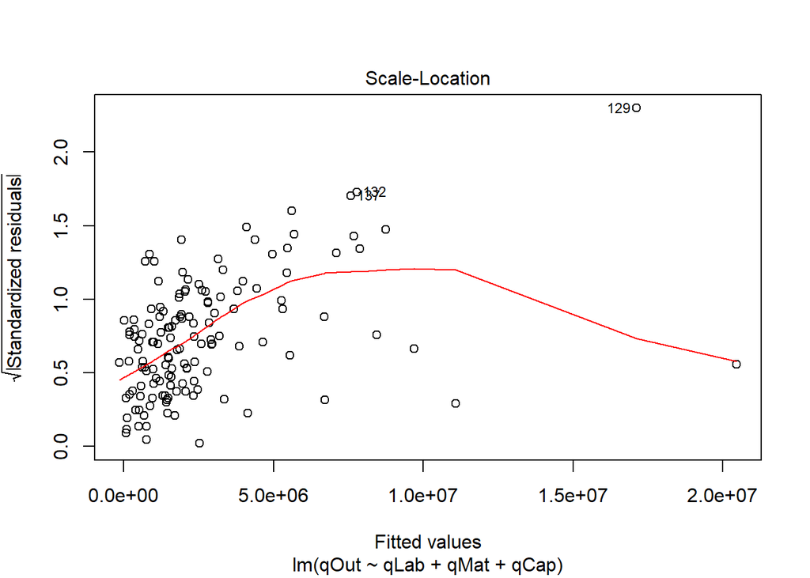

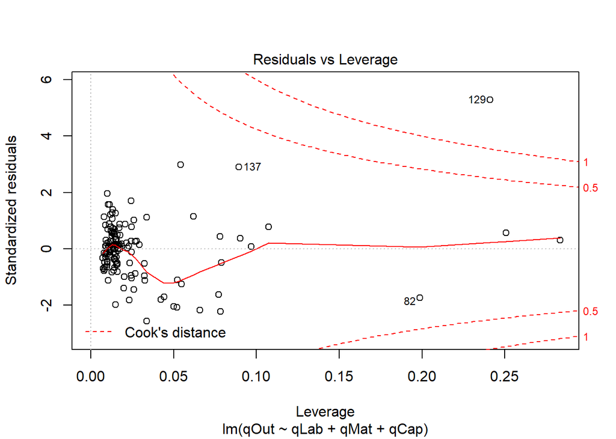

On remarque que le nuage de point s’éloigne de la ligne pointillé

Le test de Shapiro-Wilk peut également être employé pour évaluer la normalité des résidus. L’hypothèse de normalité est rejetée si la p-value est inférieure à 0.05.

```
    Shapiro-Wilk normality test

data:  residuals(lm1)
W = 0.94765, p-value = 3.941e-05
```

## Cobb-Douglass

$$q_i = A\prod_{k=1}^{3}x_{ik}^{\alpha k}\epsilon_i + w$$

```
===============================================
                        Dependent variable:
                    ---------------------------
                             log(qOut)
-----------------------------------------------
log(qLab)                    0.676***
                              (0.154)

log(qMat)                    0.627***
                              (0.126)

log(qCap)                     0.163*
                              (0.087)

Constant                      -2.064
                              (1.313)

-----------------------------------------------
Observations                    140
R2                             0.594
Adjusted R2                    0.585
Residual Std. Error      0.656 (df = 136)
F Statistic           66.412*** (df = 3; 136)
===============================================
Note:               *p<0.1; **p<0.05; ***p<0.01
```

La p-value est inférieur à 0.05 on rejette donc l’hypothèse de normalité de résidus. **Calcul des productivité marginale de chaque input**

**TMST : Taux marginale de substitution technique**

```
TMST_CapLabCD TMST_CapMatCD TMST_LabCapCD TMST_LabMatCD TMST_MatCapCD
   -1.7930063   -14.8647707    -0.8833178    -9.1750351    -0.1065985
TMST_MatLabCD
   -0.1362446
```

Le prix du capital en unité de matériaux et de 15, le prix du cap en unité de travail est de 2. Le prix du travail en unité de matériaux est de 9, cette analyse de prix de chaque input en unité des autres inputs nous informent que le meilleur input est le matériel le deuxième est le travail et enfin le dernier le capital. Notre critère de hierarchisation prend en compte les productivités moyennes, les productivité marginales et les taux marginaux de substitution techniques des 3 inputs.

Calcul de la somme des 3 variances des facteurs de production. Pour pouvoir faire le test des rendements d’échelle.

$$V(X + Y + Z) = V(X) + V(Y) + V(Z) + 2Cov(X,Y) + 2COV(X,Z) + 2COV(Y,Z)$$

```
[1] 0.0118237
```

On fait le test pour savoir si cette valeur est significativement différent de 1 pour savoir si on a des rendements constants. Les rendements sont donc croissants.

OU (autre méthode)

```
    Shapiro-Wilk normality test

data:  residuals(lm2)
W = 0.97807, p-value = 0.02369
```

```
             (Intercept)    log(qLab)    log(qMat)    log(qCap)
(Intercept)  1.722885458 -0.144645932  0.006112845 -0.001311476
log(qLab)   -0.144645932  0.023807680 -0.010226424 -0.003900608
log(qMat)    0.006112845 -0.010226424  0.015842699 -0.003589481
log(qCap)   -0.001311476 -0.003900608 -0.003589481  0.007606349
```

```
         [,1]
[1,] 1.679567
```

```
         [,1]
[1,] 1.253318
```

Les rendements d’échelle pour la cobb Douglass sont égaux à 1.46. On fait un test pour savoir s’ils sont significativement différents de 1, donc afin de voir s’ils sont croissants ou non. Or **1 n’est pas dans l’intervalle ce qui signifie que les rendements d’echelle ne sont pas constants.**

## Translog

$$q_i = \alpha + \sum_{k=1}^{3} \beta_k lnx_{ik} + \frac{1}{2} \sum_{l=1}^{3}\sum_{k=1}^{3} \beta_{kl}lnx_{ik}lnx_{il} +\epsilon_i$$

```
===============================================
                        Dependent variable:
                    ---------------------------
                             log(qOut)
-----------------------------------------------
log(qLab)                      1.993
                              (4.566)

log(qMat)                      2.232
                              (3.763)

log(qCap)                     -2.307
                              (2.288)

I(log(qMat)2)                 -0.252
                              (0.217)

I(log(qCap)2)                 -0.013
                              (0.104)

I(log(qLab)2)                 -0.582*
                              (0.340)

log(qLab):log(qMat)            0.658
                              (0.428)

log(qLab):log(qCap)           0.562*
                              (0.291)

log(qMat):log(qCap)           -0.410*
                              (0.235)

Constant                      -4.146
                             (21.359)

-----------------------------------------------
Observations                    140
R2                             0.630
Adjusted R2                    0.604
Residual Std. Error      0.641 (df = 130)
F Statistic           24.549*** (df = 9; 130)
===============================================
Note:               *p<0.1; **p<0.05; ***p<0.01
```

Très grosse colinéarité il faut faire vif test !

Test entre Cobb Douglass et Translog A faire test de Fisher où $H_0$ est le modele contraint (Cobb Douglass) et $H_1$ non contraint (Translog)

```
          log(qLab)           log(qMat)           log(qCap)
           1895.464            1984.402            1205.721
     I(log(qMat)^2)      I(log(qCap)^2)      I(log(qLab)^2)
           2705.552            1224.448            6498.838
log(qLab):log(qMat) log(qLab):log(qCap) log(qMat):log(qCap)
           9269.896            5917.589            3621.549
```

Fonction pour faire le test manuellement :

```
[1] "2.062 est inférieur à la statistique théorique de Fisher, on ne peux pas rejeter l'hypothèse nulle"
```

## Quadratique

$$q_i = \alpha + \sum_{k=1}^{3} \beta_k x_{ik} + \frac{1}{2} \sum_{l=1}^{3}\sum_{k=1}^{3} \beta_{kl}x_{ik}x_{il} +\epsilon_i$$

```
===============================================
                        Dependent variable:
                    ---------------------------
                               qOut
-----------------------------------------------
qCap                           5.270
                              (4.403)

qLab                          6.077*
                              (3.185)

qMat                          14.303
                             (24.057)

I(0.5 * qCap2)                0.0001
                             (0.00004)

I(0.5 * qLab2)               -0.00003
                             (0.00002)

I(0.5 * qMat2)               -0.002**
                              (0.001)

I(qCap * qLab)              -0.00003**
                             (0.00001)

I(qCap * qMat)               -0.00004
                             (0.0001)

I(qLab * qMat)               0.0004***
                             (0.0001)

Constant                   -291,113.100
                           (361,461.100)

-----------------------------------------------
Observations                    140
R2                             0.845
Adjusted R2                    0.834
Residual Std. Error  1,344,189.000 (df = 130)
F Statistic           78.684*** (df = 9; 130)
===============================================
Note:               *p<0.1; **p<0.05; ***p<0.01
```

## CES

```
===============================================
                        Dependent variable:
                    ---------------------------
                          log(qCap/qLab)
-----------------------------------------------
log(pLab/pCap)               0.686***
                              (0.071)

Constant                     -0.970***
                              (0.045)

-----------------------------------------------
Observations                    140
R2                             0.400
Adjusted R2                    0.396
Residual Std. Error      0.526 (df = 138)
F Statistic           92.165*** (df = 1; 138)
===============================================
Note:               *p<0.1; **p<0.05; ***p<0.01

===============================================
                        Dependent variable:
                    ---------------------------
                          log(qCap/qMat)
-----------------------------------------------
log(pMat/pCap)               0.643***
                              (0.065)

Constant                       0.020
                              (0.121)

-----------------------------------------------
Observations                    140
R2                             0.416
Adjusted R2                    0.411
Residual Std. Error      0.526 (df = 138)
F Statistic           98.144*** (df = 1; 138)
===============================================
Note:               *p<0.1; **p<0.05; ***p<0.01

```

[output cut: 64 more lines]

```
-----------------------------------------------
log(pLab/pMat)               0.332***
                              (0.090)

Constant                     -1.570***
                              (0.170)

-----------------------------------------------
Observations                    140
R2                             0.090
Adjusted R2                    0.084
Residual Std. Error      0.454 (df = 138)
F Statistic           13.704*** (df = 1; 138)
===============================================
Note:               *p<0.1; **p<0.05; ***p<0.01
```

Faire des tests de Student.

# Les fonctions de cout

## Cobb Douglass

$$c_i = A \prod_{k=1}^{3} p_{ik}^{\alpha k} q_{i}^{\alpha y} \epsilon_i$$

```
===============================================
                        Dependent variable:
                    ---------------------------
                             log(cost)
-----------------------------------------------
log(pCap)                      0.074
                              (0.049)

log(pLab)                    0.465***
                              (0.147)

log(pMat)                    0.486***
                              (0.081)

log(qOut)                    0.373***
                              (0.031)

Constant                     6.754***
                              (0.407)

-----------------------------------------------
Observations                    140
R2                             0.688
Adjusted R2                    0.679
Residual Std. Error      0.340 (df = 135)
F Statistic           74.558*** (df = 4; 135)
===============================================
Note:               *p<0.1; **p<0.05; ***p<0.01
```

## Cobb-Douglass de court terme

$$c_i = A x_{i3}^{\alpha3} \prod_{k=1}^{2} p_{ik}^{\alpha k} q_{i}^{\alpha y} \epsilon_i)$$

```
===============================================
                        Dependent variable:
                    ---------------------------
                            log(vCost)
-----------------------------------------------
log(pLab)                    0.457***
                              (0.138)

log(pMat)                    0.441***
                              (0.077)

log(qCap)                    0.192***
                              (0.040)

log(qOut)                    0.291***
                              (0.033)

Constant                     5.660***
                              (0.425)

-----------------------------------------------
Observations                    140
R2                             0.726
Adjusted R2                    0.718
Residual Std. Error      0.318 (df = 135)
F Statistic           89.629*** (df = 4; 135)
===============================================
Note:               *p<0.1; **p<0.05; ***p<0.01
```

## Translog

$$ln c_i = \alpha + \sum_{k=1}^{3} \beta_k + ln p_{ik} + \alpha_q ln(q_i)+ \frac{1}{2} \sum_{l=1}^{3}\sum_{k=1}^{3} \beta_{kl}lnp_{ik}lnp_{il} + \frac{1}{2} \alpha_{qq} (ln(q_i))² + \frac{1}{2} \sum_{k=1}^{3}\alpha_{kq}lnp_{ik}lnq_{i} + \epsilon_i$$

```
====================================================
                             Dependent variable:
                         ---------------------------
                                  log(cost)
----------------------------------------------------
log(pCap)                           0.199
                                   (0.538)

log(pLab)                          -0.025
                                   (2.232)

log(pMat)                          -1.245
                                   (1.201)

log(qOut)                         -2.040***
                                   (0.511)

I(0.5 * log(pCap)2)                -0.095
                                   (0.105)

I(0.5 * log(pLab)2)                -0.503
                                   (0.943)

I(0.5 * log(pMat)2)                 0.529
                                   (0.338)

I(log(pCap) * log(pLab))          -0.746***
                                   (0.244)

I(log(pCap) * log(pMat))            0.182
                                   (0.130)

I(log(pLab) * log(pMat))            0.139
                                   (0.433)

I(0.5 * log(qOut)2)               0.164***
                                   (0.041)

I(log(pCap) * log(qOut))           -0.028
                                   (0.043)

I(log(pLab) * log(qOut))            0.008
                                   (0.171)

I(log(pMat) * log(qOut))            0.049
                                   (0.092)

Constant                          25.383***
                                   (3.511)

----------------------------------------------------
Observations                         140
R2                                  0.768
Adjusted R2                         0.742
Residual Std. Error           0.304 (df = 125)
F Statistic               29.593*** (df = 14; 125)
====================================================
Note:                    *p<0.1; **p<0.05; ***p<0.01
```

# Calcul des cout marginaux de production. dérivée du cout // à la production (il ne sera pas constant).

$$\frac{\partial{logC}} {\partial{logQ}} \frac{Q}{C}$$

Celle qui ont le plus grand écart cout et cout moyen. Cout moyen et cout marg doivent être decroissant si rendement échelle sont croissants.

# Classement des entreprises de plusieurs façons. (par indice de prod, un autre par taux de marge, score basé sur les deux trucs précédents).

# Objectifs finals: faire classement des entreprises. Faire des propositions.

# Cobb douglass : rendement echelle mais elasticité substitutions (allen = 1)

# CES généralisation de la cobb douglass

# Si c’est différent de 1 la technologie n’est pas cobb douglass. Normalement tout est significativement différent de 1.

Part du cout du travail dans le cout total , de meme pour capital et matériaux. Part de depense relative des facteurs indépendante du niveau de production ? Part de dépenses relatives sont constantes ? Regarder distributions prx des inputs pour chaque producteurs, il y a une variabilité au niveau individuel.

# Faire tous les tests de significativité global. (à voir)

# MODELE SFA

## Cobb Douglass

$$Q= AK^{\alpha}L^{\beta}e^W$$
$$Q= AK^{\alpha}L^{\beta}e^{V-U}$$
$${\displaystyle V\sim {\mathcal {N}}(\mu ,\sigma ^{2})}.$$
$${\displaystyle U\sim {\mathcal {N^+}}(\mu ,\sigma ^{2})}.$$

$$log(Q) = constante + \alpha lnk + \beta ln L + V - U$$

```
Error Components Frontier (see Battese & Coelli 1992)
Inefficiency decreases the endogenous variable (as in a production function)
The dependent variable is logged
Iterative ML estimation terminated after 12 iterations:
log likelihood values and parameters of two successive iterations
are within the tolerance limit

final maximum likelihood estimates
            Estimate Std. Error z value  Pr(>|z|)
(Intercept) 0.228813   1.247739  0.1834 0.8544981
log(qCap)   0.160934   0.081883  1.9654 0.0493668 *
log(qLab)   0.684777   0.146797  4.6648 3.089e-06 ***
log(qMat)   0.465871   0.131588  3.5404 0.0003996 ***
sigmaSq     1.000040   0.202456  4.9396 7.830e-07 ***
gamma       0.896664   0.070952 12.6375 < 2.2e-16 ***
---
Signif. codes:  0 '***' 0.001 '**' 0.01 '*' 0.05 '.' 0.1 ' ' 1
log likelihood value: -133.8893

cross-sectional data
total number of observations = 140

mean efficiency: 0.5379937
```

Fonction qui caractèrise une technologie de prod sauf que la fonction ici représente la technologie la plus efficace.

Dans fonction de prod et sfa c’est le max que l’on peut produire avec ce que l’on peut produire.

Entre 0 et 1, écart entre production effective et ce qui est produit. (un ratio).

Fonction frontière de cout ou la le but est pas de classe les ent des ent qui produise le plus mais de classer celles qui ont le cout le plus faible.

Pour une fonction sfa de cout une entreprise inefficace va etre au dessus de la fonction frontière de cout ineffDecrease = pour inverser fonction frontiere